# Exploratory Data Analysis

eagbozo

## Russian Financial Indicators (Финансовые рынки)

This data was extracted from the open database of quotations of *currencies and precious metals* located on the site of the Central Bank of Russia. The link https://www.cbr.ru/Eng/statistics/?PrtId=finr is available for all internet users, the website is in Russian and in English.

Data source: Kaggle https://www.kaggle.com/olgabelitskaya/russian-financial-indicators

#### Variables (columns)

- date
- monetary_gold
- foreign_ exchange_reserves
- gold
- silver
- platinum
- palladium
- dual_ currency_basket
- EUR_978
- USD_840
- JPY_392
- CNY_156
- INR_356
- BRL_986

### Load Dataset

```r
df = read.csv("c_bank.csv")
```

### Splitting Dataset in Training and Testing Dataframes

We will work with the training dataset in order for our computers to run our algorithms quicker. Upon completion of our models, we can then visualize with our full dataset

```r
n = nrow(df)
trainIndex = sample(1:n, size = round(0.2*n), replace=FALSE)
df_train = df[trainIndex ,]
df_test = df[-trainIndex ,]
```

Let’s get the variable names

```r
names(df_train)
```

```
##  [1] "date"                      "monetary_gold"
##  [3] "foreign_exchange_reserves" "gold"
##  [5] "silver"                    "platinum"
##  [7] "palladium"                 "dual_currency_basket"
##  [9] "EUR_978"                   "USD_840"
## [11] "JPY_392"                   "CNY_156"
## [13] "INR_356"                   "BRL_986"
```

### Plotting with *ggplot2*

*ggplot2* is a system for declaratively creating graphics, based on The Grammar of Graphics. You provide the data, tell ggplot2 how to map variables to aesthetics, what graphical primitives to use, and it takes care of the details. (Source https://ggplot2.tidyverse.org/index.html )

To install the package:

```r
#install.packages("ggplot")

#OR we can install it by installing the TidyVerse package
#install.packages("tidyverse")
```

Download the *ggplot2 Cheat Sheet* here: https://github.com/rstudio/cheatsheets/raw/master/data-visualization-2.1.pdf

Load the package and begin plotting

```r
library(ggplot2)
```

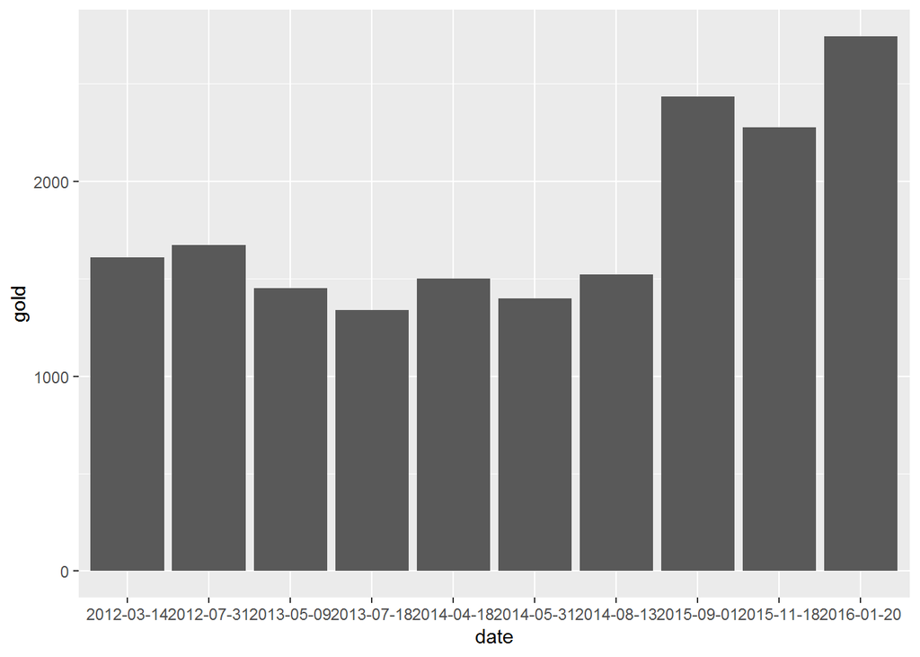

```r
#A sample plot for first 10 of our training dataset
ggplot(df_train[1:10,], aes(date,gold))+
  geom_bar(stat = "identity")
```

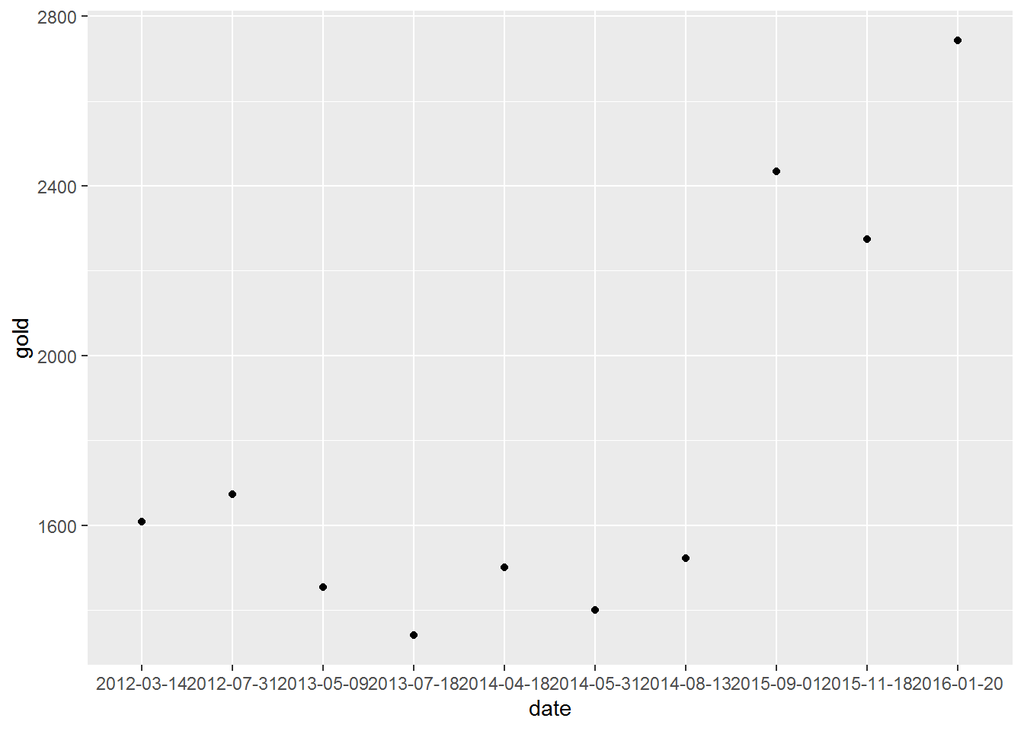

```r
#we can also plot points
ggplot(df_train[1:10,]) +
  geom_point(aes(date,gold))
```

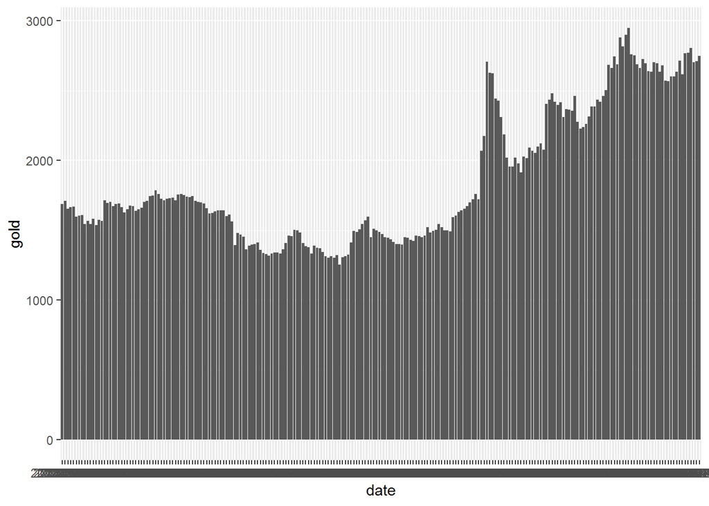

```r
#full plot of gold stats
ggplot(df_train, aes(date,gold))+
  geom_bar(stat = "identity")
```

By default, geom_ bar uses *stat=“count”* which makes the height of the bar proportion to the number of cases in each group (or if the weight aethetic is supplied, the sum of the weights). If you want the heights of the bars to represent values in the data, use stat=“identity” and map a variable to the y aesthetic.

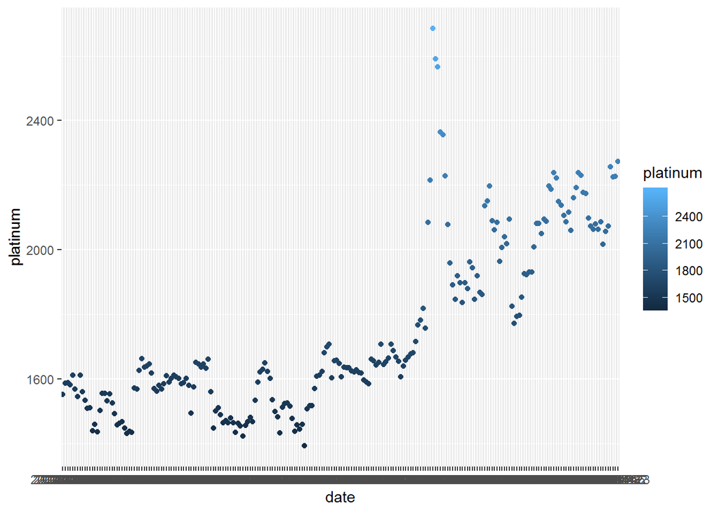

```r
#plot platinum stats
ggplot(df_train, aes(date,platinum)) +
  geom_point(aes(colour = platinum)) #replace colour = platinum ----> colour = "platinum"
```

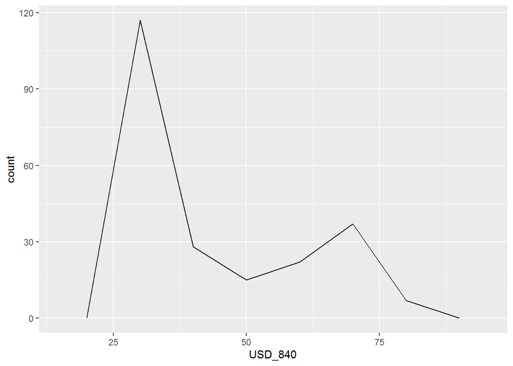

```r
ggplot(df_train, aes(USD_840, colour = silver)) +
  geom_freqpoly(binwidth = 10)
```

```r
library(tidyverse)
```

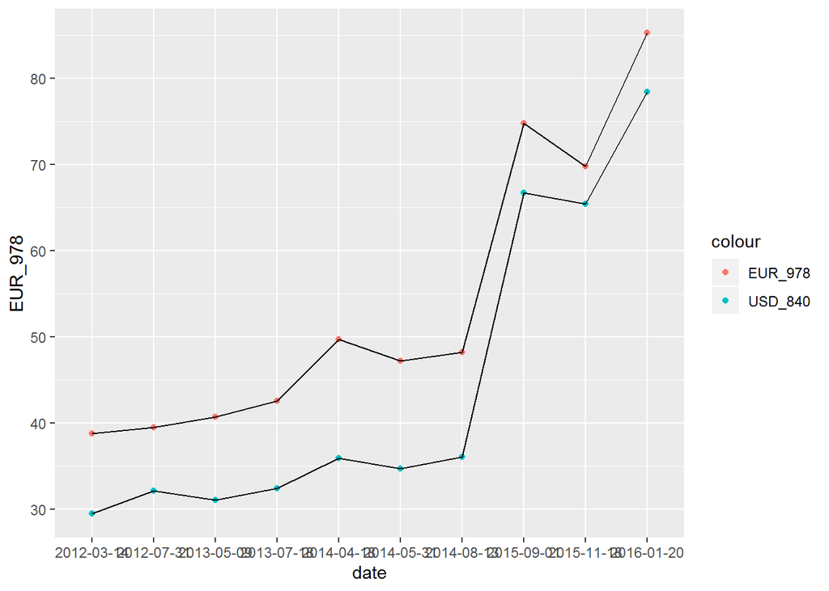

```r
  ggplot(df_train[1:10,],aes(x=date)) +
  geom_point(aes(y = EUR_978, colour = "EUR_978")) +
  geom_point(aes(y = USD_840, colour = "USD_840"))+
    geom_line(aes(y = EUR_978, group=1))+
    geom_line(aes(y = USD_840,group=1))
```

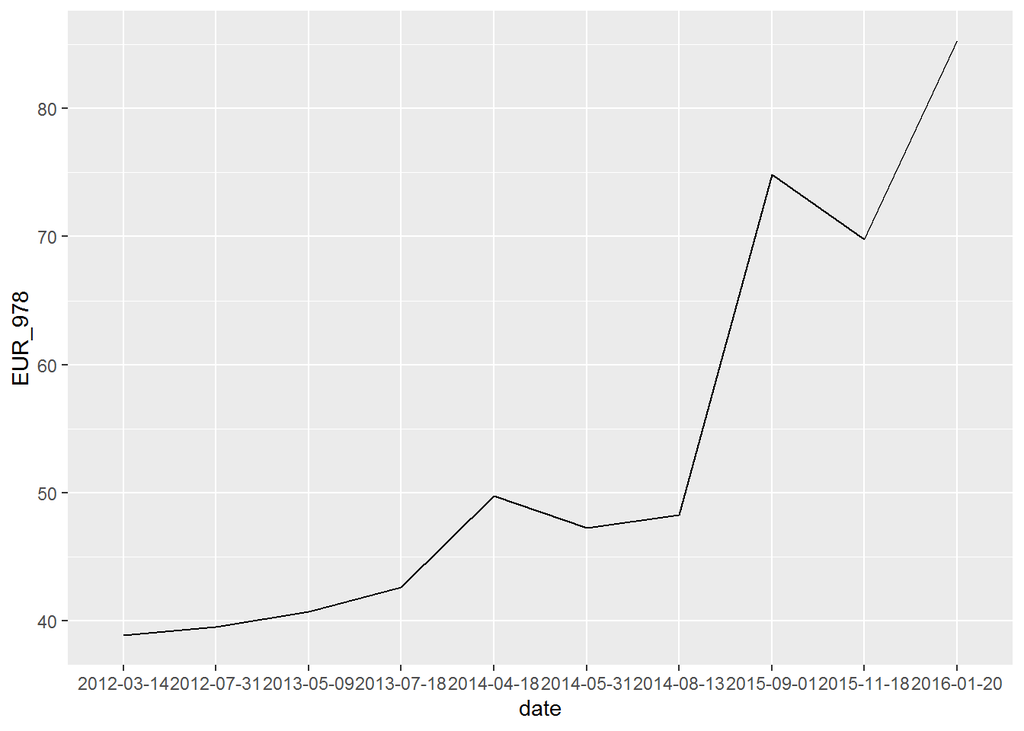

```r
#we will plot the Euro - Ruble rate over time - with the training
ggplot(df_train[1:10,],aes(date,EUR_978, group=1)) +
  geom_line(aes())
```

```r
#We will use the RESHAPE2 library
#This function reshapes a data frame between ‘wide’ format with repeated measurements in separate columns of the same record and ‘long’ format with the repeated measurements in separate records.
library(reshape2)
```

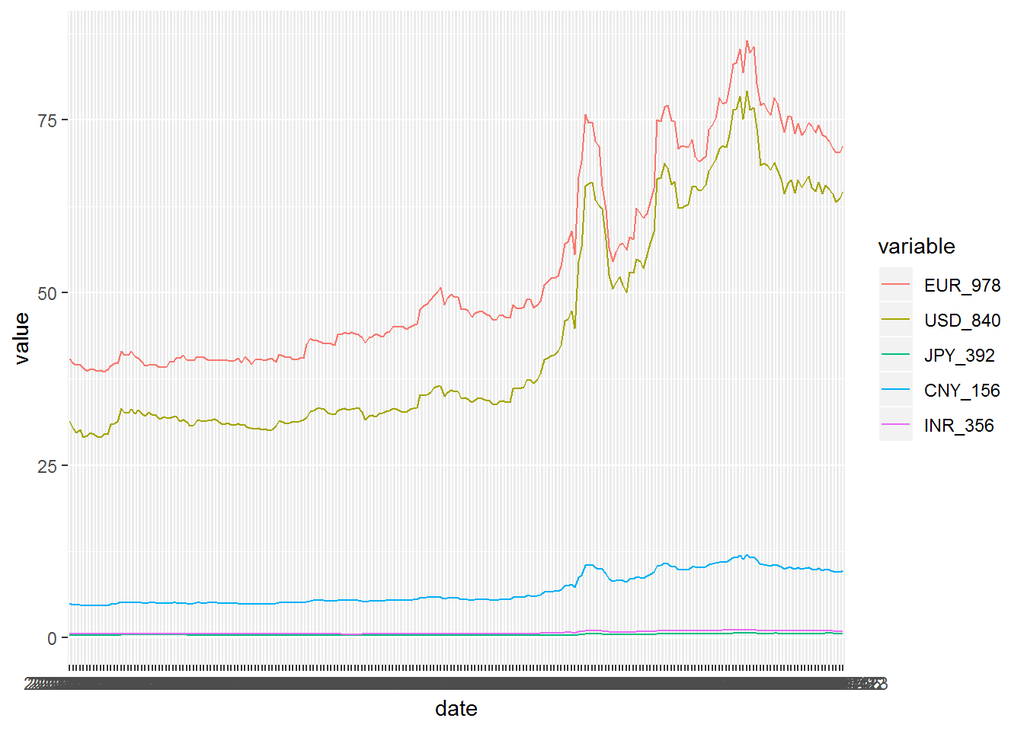

```r
test_data_long <- melt(df_train[,c(1,9:13)], id="date")  # convert to long format
ggplot(data=test_data_long,
       aes(x=date, y=value, colour=variable, group=variable)) +
       geom_line()
```

To understand GGPLOT check out these links:

1. Be Awesome in ggplot2: A Practical Guide to be Highly Effective - R software and data visualization http://www.sthda.com/english/wiki/be-awesome-in-ggplot2-a-practical-guide-to-be-highly-effective-r-software-and-data-visualization
2. ggplot2 https://ggplot2.tidyverse.org/index.html

### Exploratory Data Analysis (EDA)

EDA is to develop an understanding of your data. Questions are used as tools to guide the process. *There is no rule about which questions you should ask to guide your research.* Source: https://r4ds.had.co.nz/exploratory-data-analysis.html#introduction-3